# Coupon Bight Aquatic Preserve

SEACAR Water Quality Analysis

Last compiled on 15 July, 2026

# Indicators

## Nutrients

### Total Nitrogen - Discrete

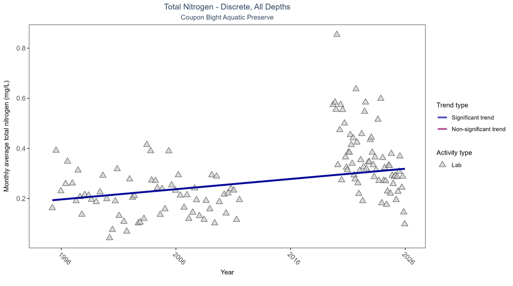

Scatter plot of monthly average total nitrogen over time. If the time series included ten or more years of discrete observations, a significant (blue) or non-significant (magenta) trend line is also shown. Only nitrogen values obtained from laboratory analyses (triangles) are included in the plot.

Table:

Monthly average total nitrogen increased by less than 0.01 mg/L per year.

| Activity Type | Statistical Trend | Sample Count | Years with Data | Period of Record | Median Result Value | Tau | Sen Intercept | Sen Slope | P |
| --- | --- | --- | --- | --- | --- | --- | --- | --- | --- |
| Lab | Increasing trend | 224 | 24 | 1995 - 2025 | 0.2599 | 0.2295 | 0.19234 | 0.00408 | 0.0013 |

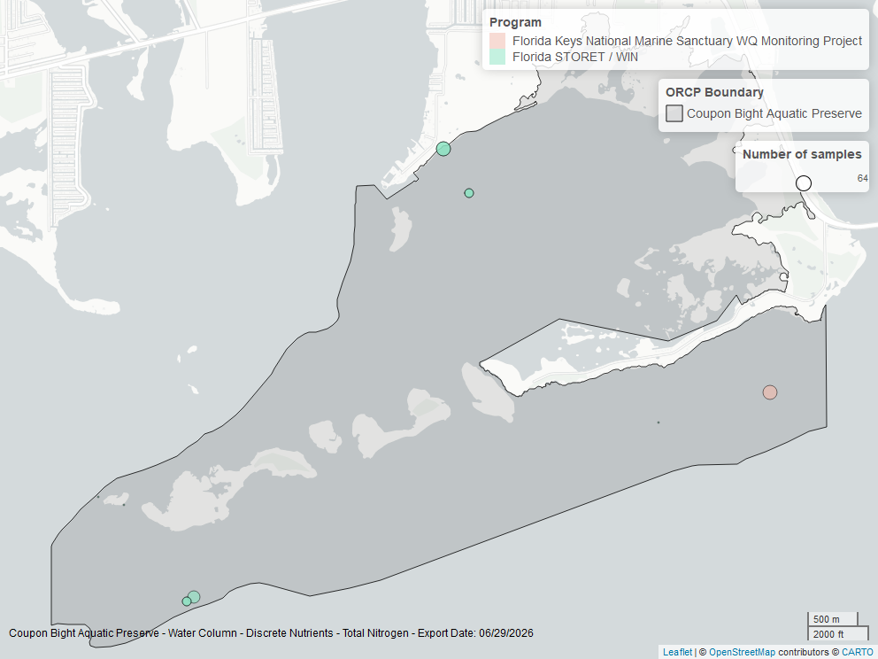

Map showing location of discrete water quality sampling locations within the boundaries of *Coupon Bight Aquatic Preserve*. The bubble size on the maps above reflect the amount of data available at each sampling site.

### Total Phosphorus - Discrete

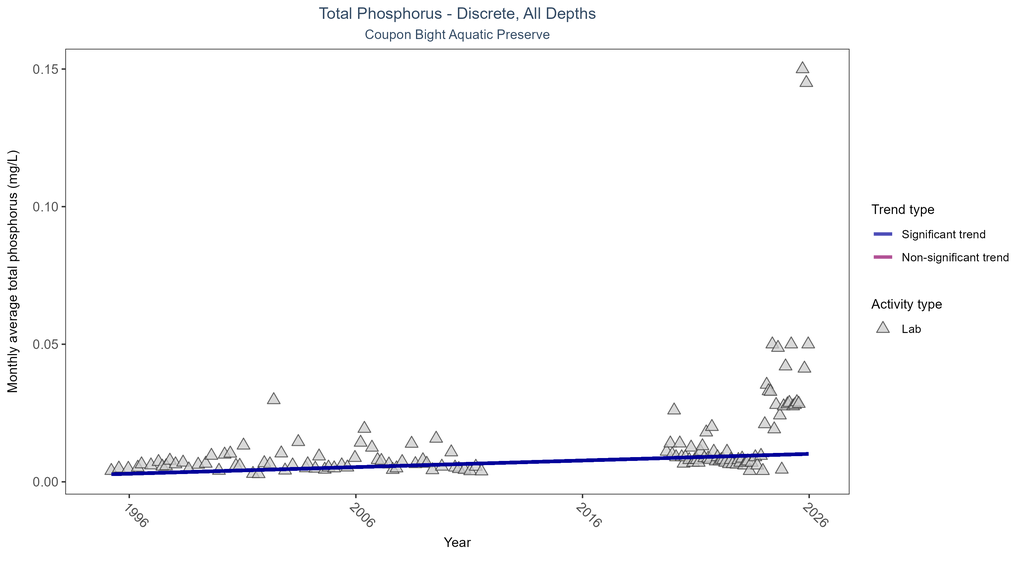

Scatter plot of monthly average total phosphorus over time. If the time series included ten or more years of discrete observations, a significant (blue) or non-significant (magenta) trend line is also shown. Only phosphorus values obtained from laboratory analyses (triangles) are included in the plot.

Table:

Monthly average total phosphorus increased by less than 0.01 mg/L per year.

| Activity Type | Statistical Trend | Sample Count | Years with Data | Period of Record | Median Result Value | Tau | Sen Intercept | Sen Slope | P |
| --- | --- | --- | --- | --- | --- | --- | --- | --- | --- |
| Lab | Increasing trend | 225 | 24 | 1995 - 2025 | 0.008 | 0.41641 | 0.00271 | 0.00024 | 0 |

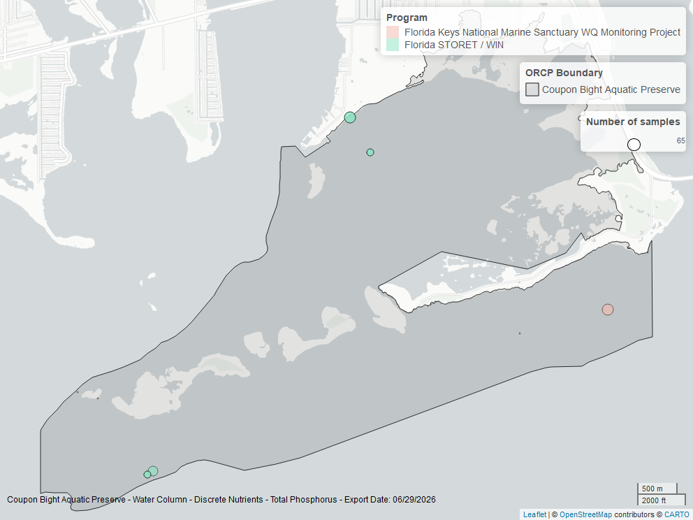

Map showing location of discrete water quality sampling locations within the boundaries of *Coupon Bight Aquatic Preserve*. The bubble size on the maps above reflect the amount of data available at each sampling site.

## Water Quality

### Dissolved Oxygen - Continuous

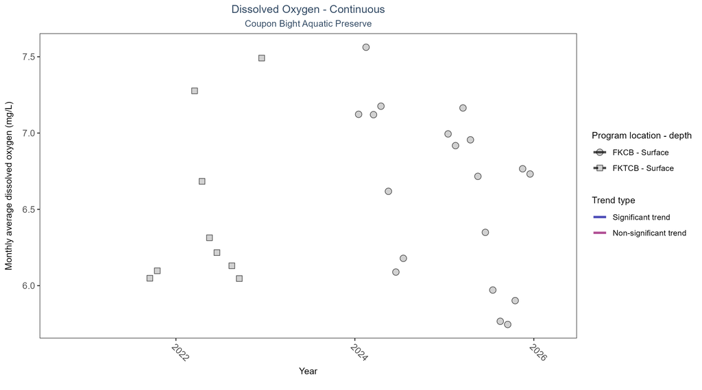

Scatter plot of monthly average dissolved oxygen over time at continuously monitored program locations. Each location is analyzed separately, with significant (blue) or non-significant (magenta) trend lines shown for time series that included five or more years of observations.

Table:

There was insufficient data to fit a model for two locations.

| Program Location | Statistical Trend | Sample Count | Years with Data | Period of Record | Median Result Value | Tau | Sen Intercept | Sen Slope | P |
| --- | --- | --- | --- | --- | --- | --- | --- | --- | --- |
| FKCB | Insufficient data | 46023 | 2 | 2024 - 2025 | 6.5 | - | - | - | - |
| FKTCB | Insufficient data | 13514 | 2 | 2021 - 2022 | 6.4 | - | - | - | - |

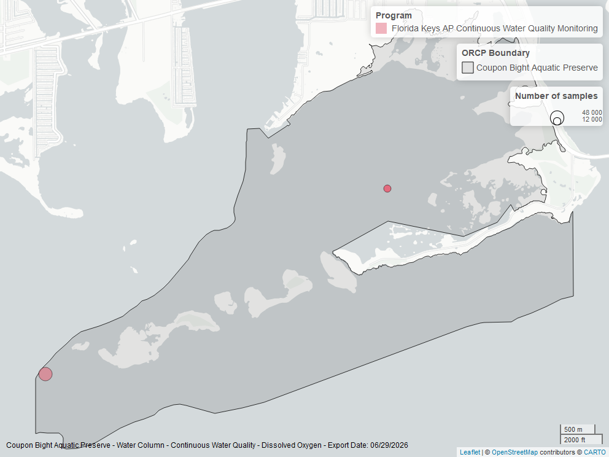

Map showing location of dissolved oxygen continuous water quality sampling locations within the boundaries of *Coupon Bight Aquatic Preserve*. The bubble size on the maps above reflect the amount of data available at each sampling site.

### Dissolved Oxygen - Discrete

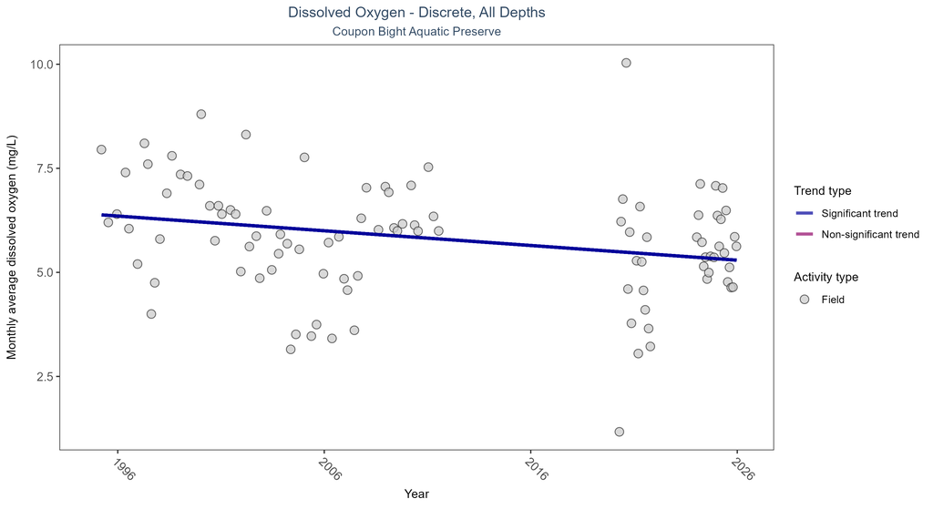

Scatter plot of monthly average dissolved oxygen over time. If the time series included ten or more years of discrete observations, a significant (blue) or non-significant (magenta) trend line is also shown. Only dissolved oxygen values measured in the field (circles) are included in the plot.

Table:

Monthly average dissolved oxygen decreased by 0.04 mg/L per year.

| Activity Type | Statistical Trend | Sample Count | Years with Data | Period of Record | Median Result Value | Tau | Sen Intercept | Sen Slope | P |
| --- | --- | --- | --- | --- | --- | --- | --- | --- | --- |
| Field | Decreasing trend | 198 | 21 | 1995 - 2025 | 5.98421 | -0.19346 | 6.38843 | -0.03536 | 0.0179 |

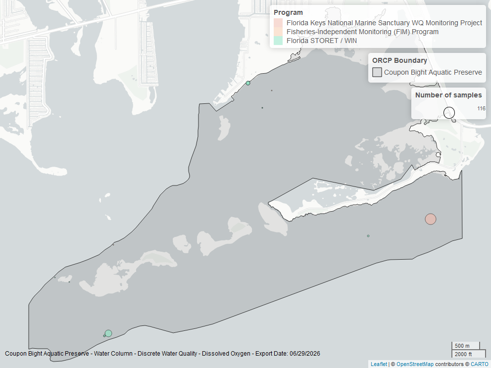

Map showing location of discrete water quality sampling locations within the boundaries of *Coupon Bight Aquatic Preserve*. The bubble size on the maps above reflect the amount of data available at each sampling site.

### Dissolved Oxygen Saturation - Continuous

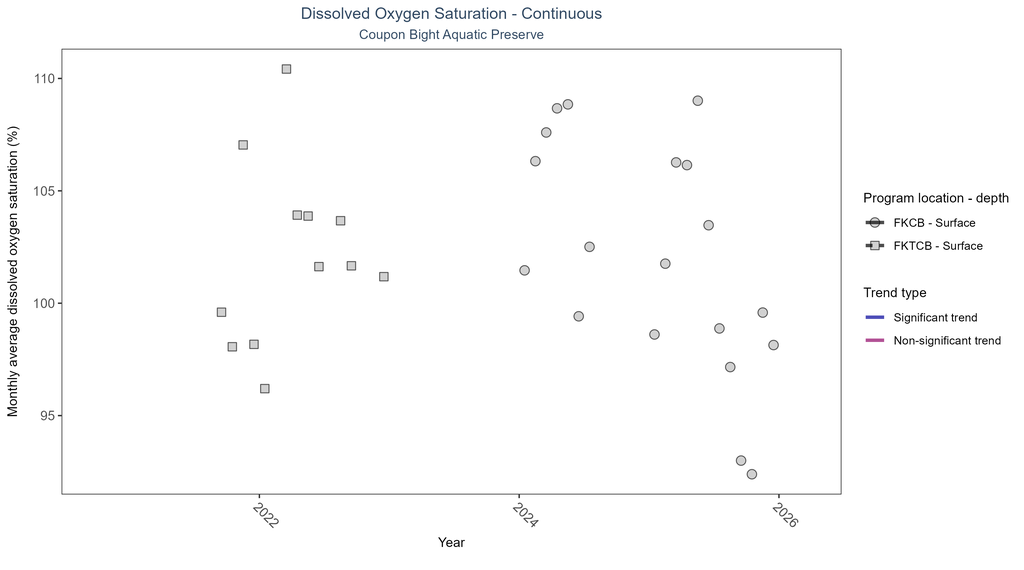

Scatter plot of monthly average dissolved oxygen saturation over time at continuously monitored program locations. Each location is analyzed separately, with significant (blue) or non-significant (magenta) trend lines shown for time series that included five or more years of observations.

Table:

There was insufficient data to fit a model for two locations.

| Program Location | Statistical Trend | Sample Count | Years with Data | Period of Record | Median Result Value | Tau | Sen Intercept | Sen Slope | P |
| --- | --- | --- | --- | --- | --- | --- | --- | --- | --- |
| FKCB | Insufficient data | 46055 | 2 | 2024 - 2025 | 100.5 | - | - | - | - |
| FKTCB | Insufficient data | 17063 | 2 | 2021 - 2022 | 100.2 | - | - | - | - |

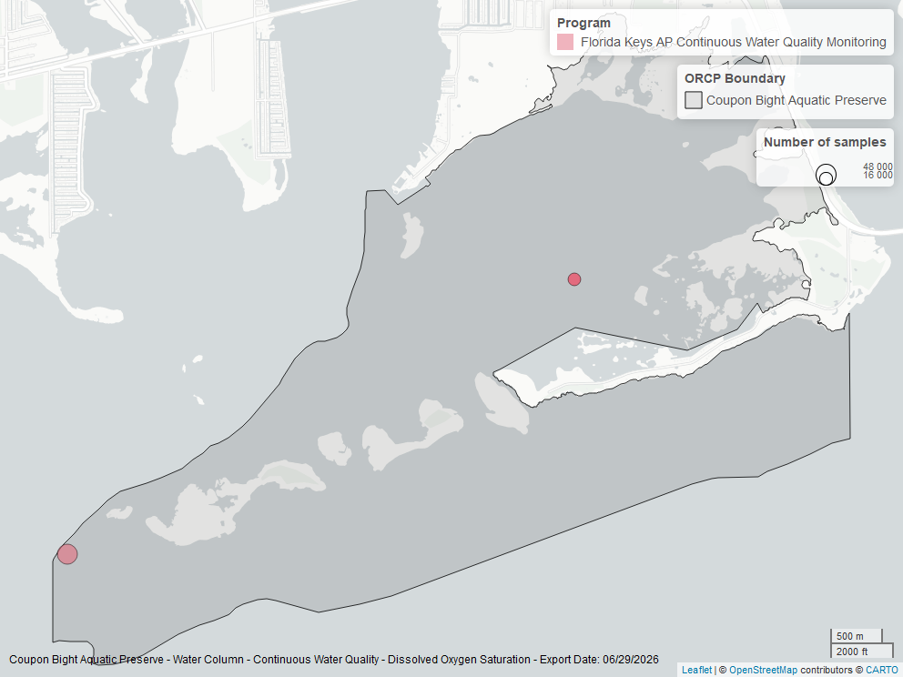

Map showing location of dissolved oxygen saturation continuous water quality sampling locations within the boundaries of *Coupon Bight Aquatic Preserve*. The bubble size on the maps above reflect the amount of data available at each sampling site.

### Dissolved Oxygen Saturation - Discrete

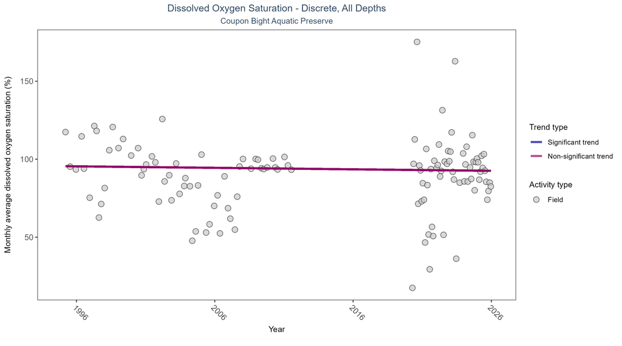

Scatter plot of monthly average dissolved oxygen saturation over time. If the time series included ten or more years of discrete observations, a significant (blue) or non-significant (magenta) trend line is also shown. Only dissolved oxygen saturation values measured in the field (circles) are included in the plot.

Table:

Dissolved oxygen saturation showed no detectable trend between 1995 and 2025.

| Activity Type | Statistical Trend | Sample Count | Years with Data | Period of Record | Median Result Value | Tau | Sen Intercept | Sen Slope | P |
| --- | --- | --- | --- | --- | --- | --- | --- | --- | --- |
| Field | No detectable trend | 255 | 23 | 1995 - 2025 | 93.1 | -0.05479 | 95.51341 | -0.09535 | 0.5271 |

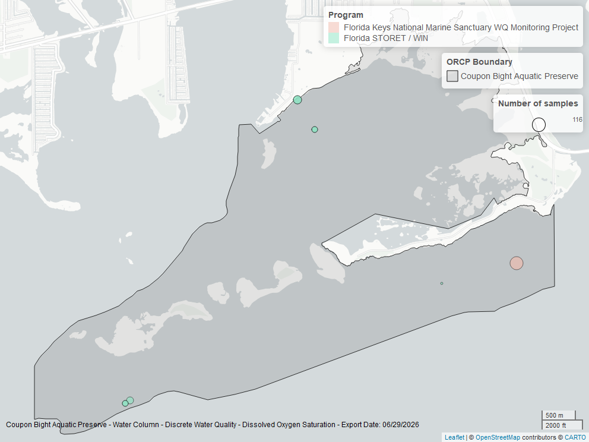

Map showing location of discrete water quality sampling locations within the boundaries of *Coupon Bight Aquatic Preserve*. The bubble size on the maps above reflect the amount of data available at each sampling site.

### Salinity - Discrete

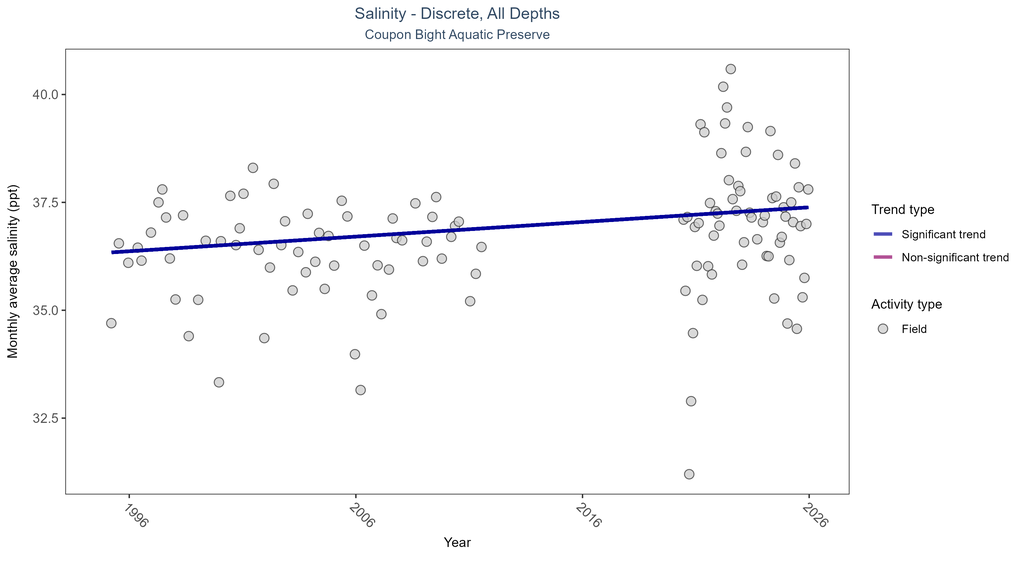

Scatter plot of monthly average salinity over time. If the time series included ten or more years of discrete observations, significant (blue) or non-significant (magenta) trend lines are also shown. Discrete salinity values derived from grab samples analyzed in the field (circles) or the laboratory (triangles) are both included in the plot.

Table:

Monthly average salinity increased by 0.03 ppt per year.

| Activity Type | Statistical Trend | Sample Count | Years with Data | Period of Record | Median Result Value | Tau | Sen Intercept | Sen Slope | P |
| --- | --- | --- | --- | --- | --- | --- | --- | --- | --- |
| All | Increasing trend | 259 | 23 | 1995 - 2025 | 36.7537 | 0.21355 | 36.33345 | 0.03393 | 0.0005 |

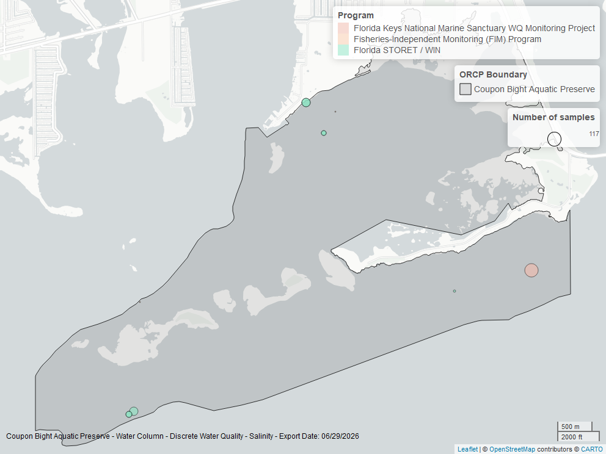

Map showing location of discrete water quality sampling locations within the boundaries of *Coupon Bight Aquatic Preserve*. The bubble size on the maps above reflect the amount of data available at each sampling site.

### Salinity - Continuous

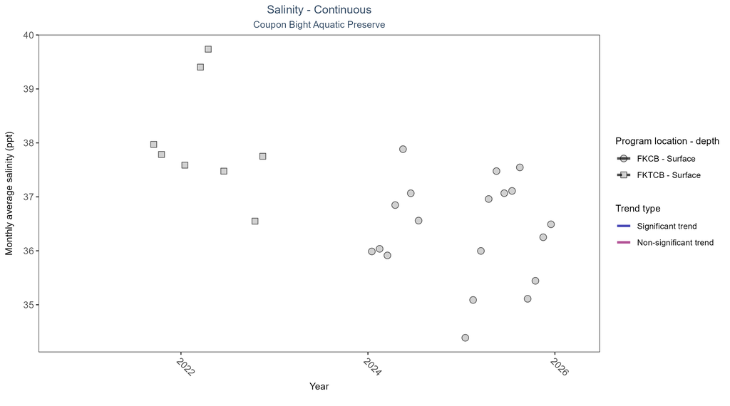

Scatter plot of monthly average salinity over time at continuously monitored program locations. Each location is analyzed separately, with significant (blue) or non-significant (magenta) trend lines shown for time series that included five or more years of observations.

Table:

There was insufficient data to fit a model for two locations.

| Program Location | Statistical Trend | Sample Count | Years with Data | Period of Record | Median Result Value | Tau | Sen Intercept | Sen Slope | P |
| --- | --- | --- | --- | --- | --- | --- | --- | --- | --- |
| FKCB | Insufficient data | 48788 | 2 | 2024 - 2025 | 36.5 | - | - | - | - |
| FKTCB | Insufficient data | 13641 | 2 | 2021 - 2022 | 37.9 | - | - | - | - |

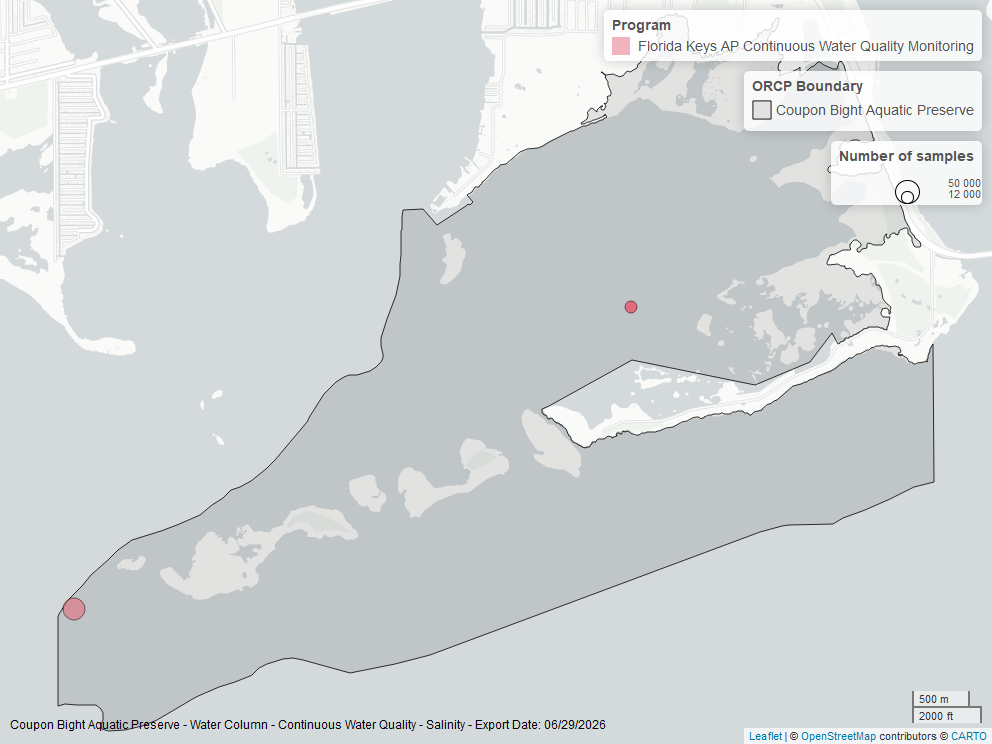

Map showing location of salinity continuous water quality sampling locations within the boundaries of *Coupon Bight Aquatic Preserve*. The bubble size on the maps above reflect the amount of data available at each sampling site.

### Water Temperature - Continuous

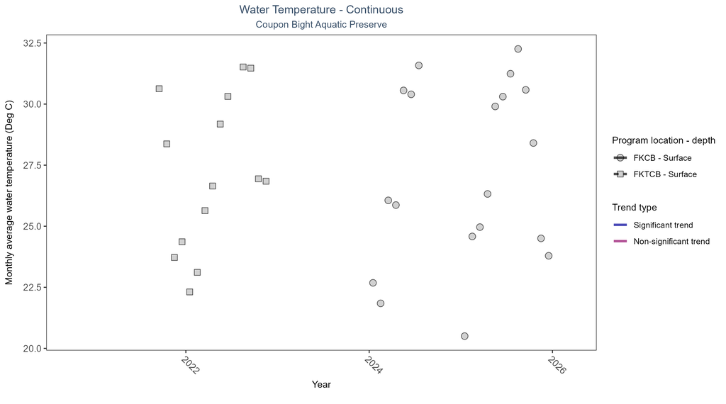

Scatter plot of monthly average water temperature over time at continuously monitored program locations. Each location is analyzed separately, with significant (blue) or non-significant (magenta) trend lines shown for time series that included five or more years of observations.

Table:

There was insufficient data to fit a model for two locations.

| Program Location | Statistical Trend | Sample Count | Years with Data | Period of Record | Median Result Value | Tau | Sen Intercept | Sen Slope | P |
| --- | --- | --- | --- | --- | --- | --- | --- | --- | --- |
| FKCB | Insufficient data | 48829 | 2 | 2024 - 2025 | 27.4 | - | - | - | - |
| FKTCB | Insufficient data | 30145 | 2 | 2021 - 2022 | 26.7 | - | - | - | - |

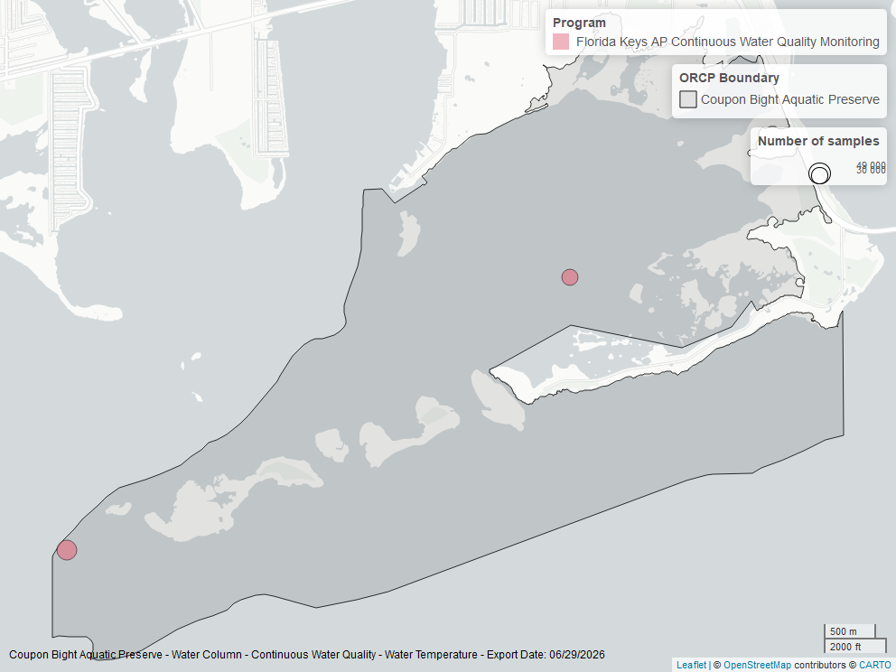

Map showing location of water temperature continuous water quality sampling locations within the boundaries of *Coupon Bight Aquatic Preserve*. The bubble size on the maps above reflect the amount of data available at each sampling site.

### Water Temperature - Discrete

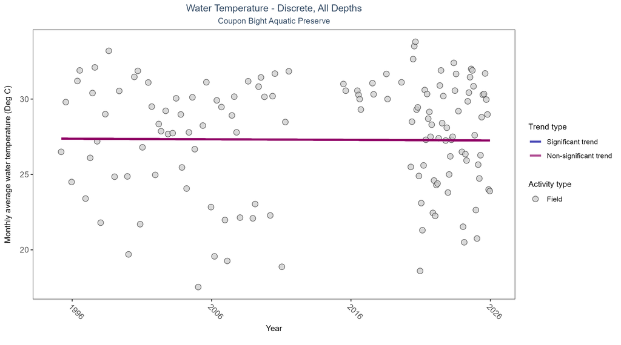

Scatter plot of monthly average water temperature over time. If the time series included ten or more years of discrete observations, a significant (blue) or non-significant (magenta) trend line is also shown. Only water temperature measurements taken in the field (circles) are included in the plot.

Table:

Water temperature showed no detectable trend between 1995 and 2025.

| Activity Type | Statistical Trend | Sample Count | Years with Data | Period of Record | Median Result Value | Tau | Sen Intercept | Sen Slope | P |
| --- | --- | --- | --- | --- | --- | --- | --- | --- | --- |
| Field | No detectable trend | 307 | 28 | 1995 - 2025 | 28.88889 | -0.01426 | 27.37571 | -0.0039 | 0.6503 |

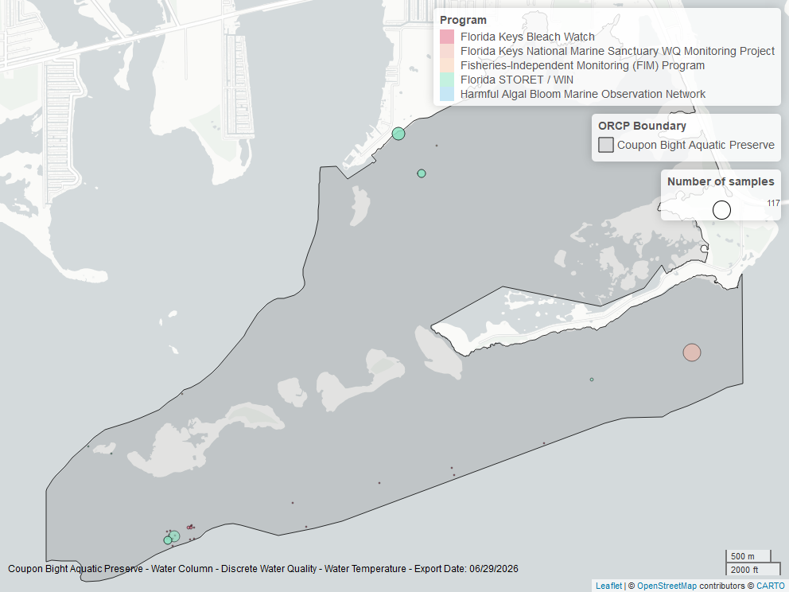

Map showing location of discrete water quality sampling locations within the boundaries of *Coupon Bight Aquatic Preserve*. The bubble size on the maps above reflect the amount of data available at each sampling site.

### pH - Continuous

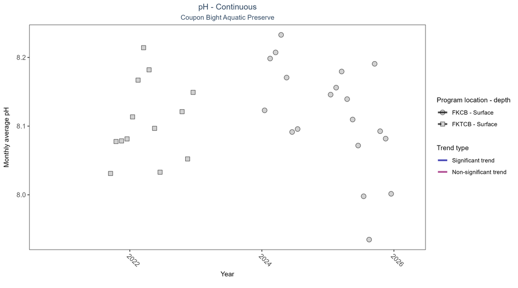

Scatter plot of monthly average pH over time at continuously monitored program locations. Each location is analyzed separately, with significant (blue) or non-significant (magenta) trend lines shown for time series that included five or more years of observations.

Table:

There was insufficient data to fit a model for two locations.

| Program Location | Statistical Trend | Sample Count | Years with Data | Period of Record | Median Result Value | Tau | Sen Intercept | Sen Slope | P |
| --- | --- | --- | --- | --- | --- | --- | --- | --- | --- |
| FKCB | Insufficient data | 48063 | 2 | 2024 - 2025 | 8.1 | - | - | - | - |
| FKTCB | Insufficient data | 22914 | 2 | 2021 - 2022 | 8.1 | - | - | - | - |

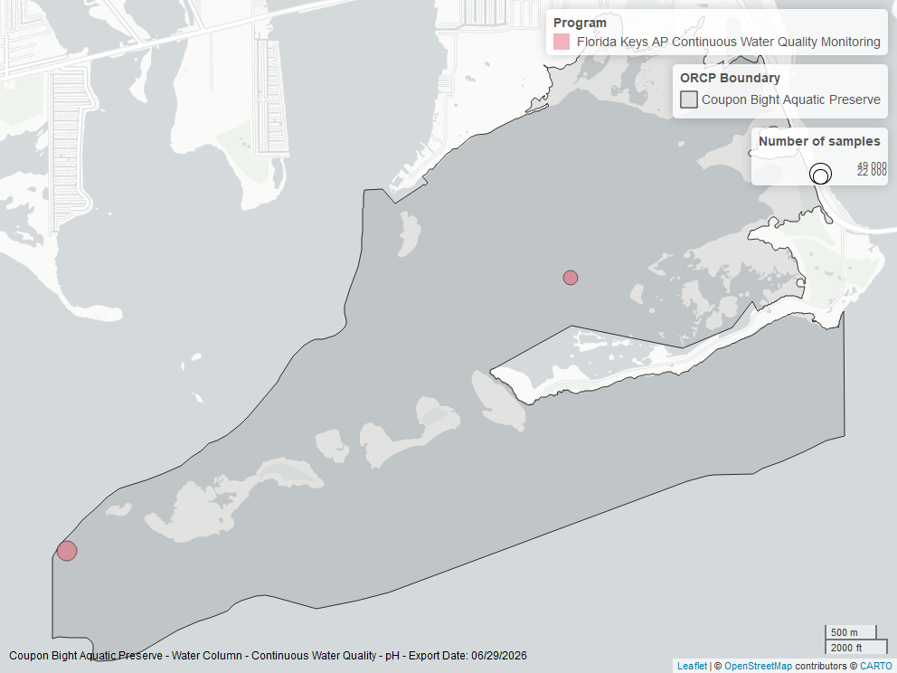

Map showing location of ph continuous water quality sampling locations within the boundaries of *Coupon Bight Aquatic Preserve*. The bubble size on the maps above reflect the amount of data available at each sampling site.

### pH - Discrete

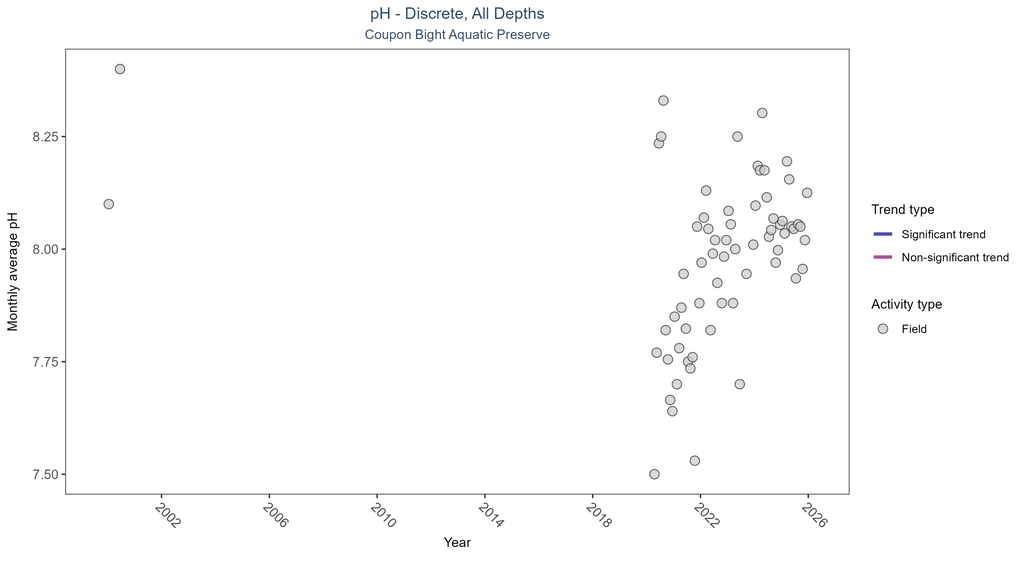

Scatter plot of monthly average pH over time. If the time series included ten or more years of discrete observations, a significant (blue) or non-significant (magenta) trend line is also shown. Only pH values measured in the field (circles) are included in the plot.

Table:

There was insufficient data to fit a model for pH.

| Activity Type | Statistical Trend | Sample Count | Years with Data | Period of Record | Median Result Value | Tau | Sen Intercept | Sen Slope | P |
| --- | --- | --- | --- | --- | --- | --- | --- | --- | --- |
| Field | Insufficient data | 158 | 7 | 2000 - 2025 | 8.03 | - | - | - | - |

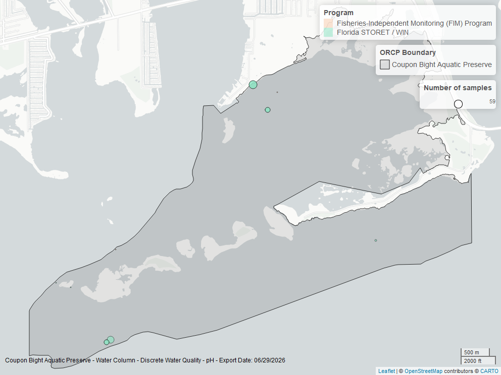

Map showing location of discrete water quality sampling locations within the boundaries of *Coupon Bight Aquatic Preserve*. The bubble size on the maps above reflect the amount of data available at each sampling site.

### Specific Conductivity - Continuous

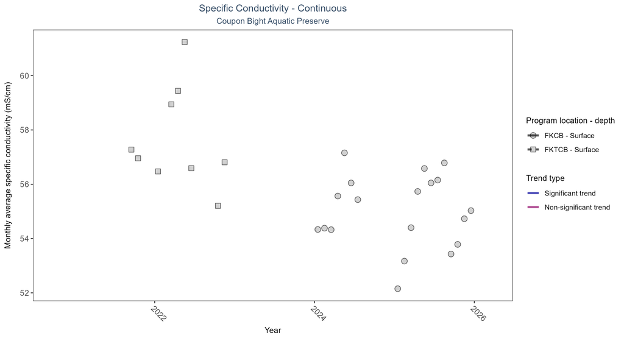

Scatter plot of monthly average specific conductivity over time at continuously monitored program locations. Each location is analyzed separately, with significant (blue) or non-significant (magenta) trend lines shown for time series that included five or more years of observations.

Table:

There was insufficient data to fit a model for two locations.

| Program Location | Statistical Trend | Sample Count | Years with Data | Period of Record | Median Result Value | Tau | Sen Intercept | Sen Slope | P |
| --- | --- | --- | --- | --- | --- | --- | --- | --- | --- |
| FKCB | Insufficient data | 48788 | 2 | 2024 - 2025 | 55.09 | - | - | - | - |
| FKTCB | Insufficient data | 13641 | 2 | 2021 - 2022 | 57.01 | - | - | - | - |

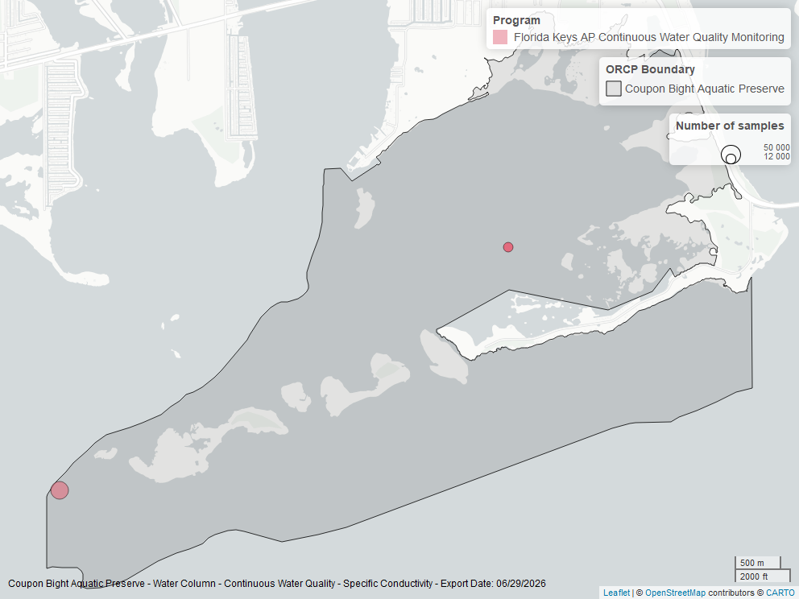

Map showing location of specific conductivity continuous water quality sampling locations within the boundaries of *Coupon Bight Aquatic Preserve*. The bubble size on the maps above reflect the amount of data available at each sampling site.

## Water Clarity

### Turbidity - Continuous

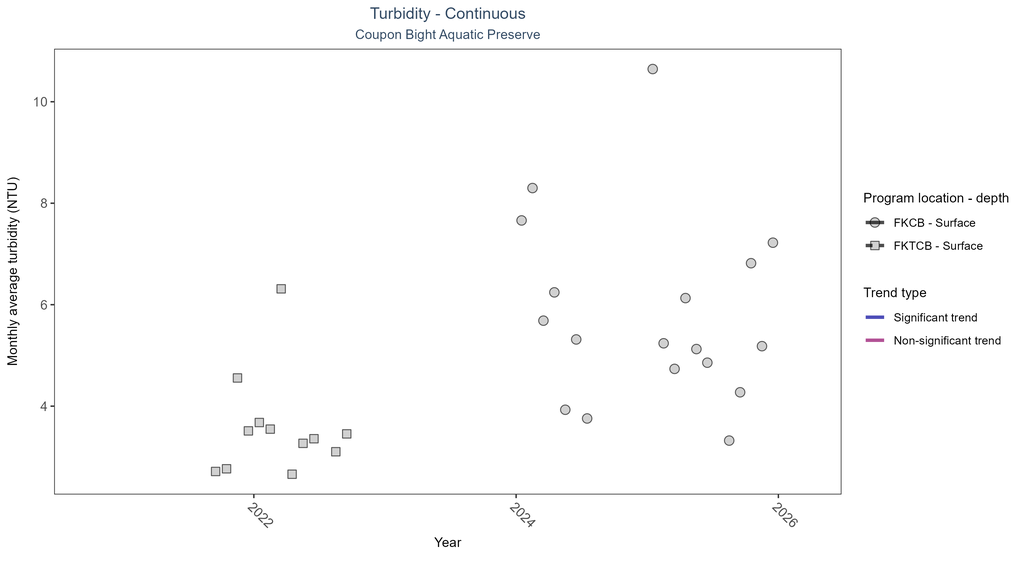

Scatter plot of monthly average turbidity over time at continuously monitored program locations. Each location is analyzed separately, with significant (blue) or non-significant (magenta) trend lines shown for time series that included five or more years of observations.

Table:

There was insufficient data to fit a model for two locations.

| Program Location | Statistical Trend | Sample Count | Years with Data | Period of Record | Median Result Value | Tau | Sen Intercept | Sen Slope | P |
| --- | --- | --- | --- | --- | --- | --- | --- | --- | --- |
| FKCB | Insufficient data | 37724 | 2 | 2024 - 2025 | 4 | - | - | - | - |
| FKTCB | Insufficient data | 19289 | 2 | 2021 - 2022 | 3 | - | - | - | - |

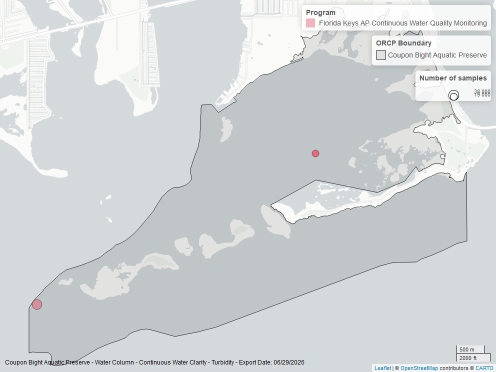

Map showing location of turbidity continuous water quality sampling locations within the boundaries of *Coupon Bight Aquatic Preserve*. The bubble size on the maps above reflect the amount of data available at each sampling site.

### Turbidity - Discrete

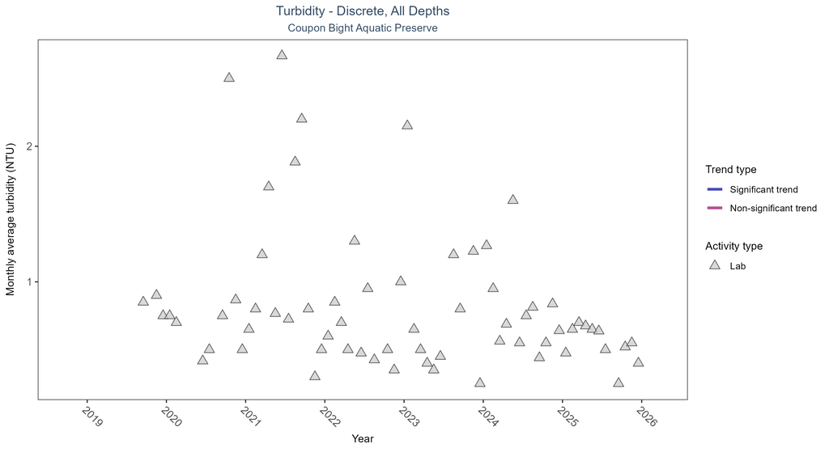

Scatter plot of monthly average turbidity over time. If the time series included ten or more years of discrete observations, a significant (blue) or non-significant (magenta) trend line is also shown. Only turbidity values measured in the laboratory (triangles) are included in the plot.

Table:

There was insufficient data to fit a model for turbidity.

| Activity Type | Statistical Trend | Sample Count | Years with Data | Period of Record | Median Result Value | Tau | Sen Intercept | Sen Slope | P |
| --- | --- | --- | --- | --- | --- | --- | --- | --- | --- |
| Lab | Insufficient data | 156 | 7 | 2019 - 2025 | 0.6 | - | - | - | - |

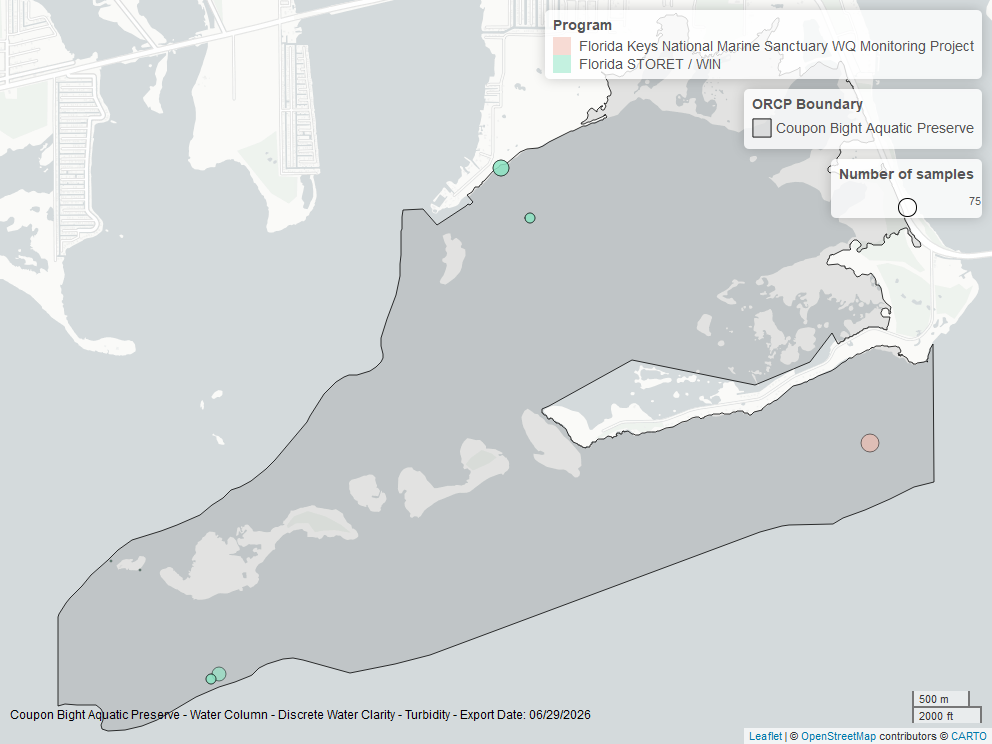

Map showing location of discrete water quality sampling locations within the boundaries of *Coupon Bight Aquatic Preserve*. The bubble size on the maps above reflect the amount of data available at each sampling site.

### Chlorophyll a, Uncorrected for Pheophytin - Discrete

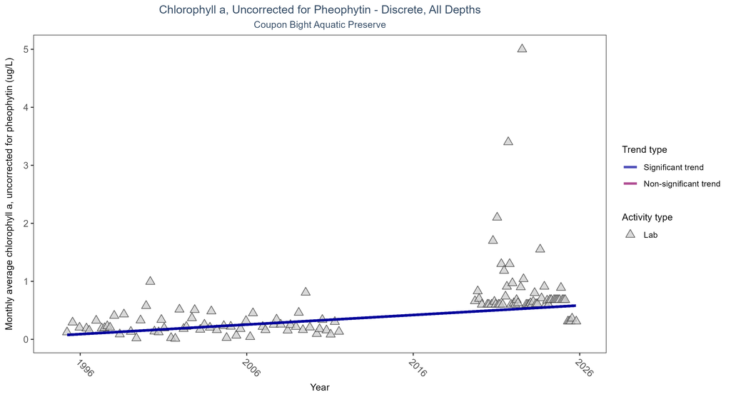

Scatter plot of monthly average levels of chlorophyll a, uncorrected for pheophytin, over time. If the time series included ten or more years of discrete observations, a significant (blue) or non-significant (magenta) trend line is also shown. Only laboratory-analyzed chlorophyll a (triangles) is included in the plot.

Table:

Monthly average chlorophyll a, uncorrected for pheophytin, increased by 0.02 µg/L per year, indicating a decrease in water clarity.

| Activity Type | Statistical Trend | Sample Count | Years with Data | Period of Record | Median Result Value | Tau | Sen Intercept | Sen Slope | P |
| --- | --- | --- | --- | --- | --- | --- | --- | --- | --- |
| Lab | Increasing trend | 173 | 24 | 1995 - 2025 | 0.6 | 0.43574 | 0.07295 | 0.01651 | 0 |

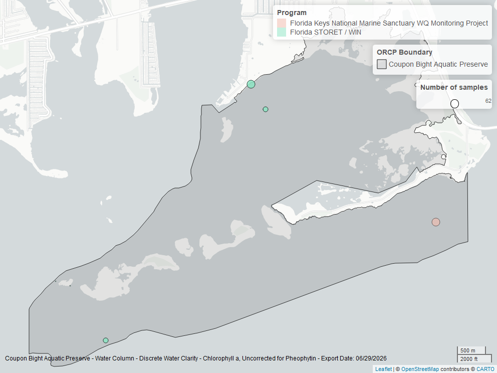

Map showing location of discrete water quality sampling locations within the boundaries of *Coupon Bight Aquatic Preserve*. The bubble size on the maps above reflect the amount of data available at each sampling site.